# TAREA_5

**Entrega de Tarea 5 - Refinitiv**

```r
#summary(cars)
```

```r
library(quantmod)
library(PerformanceAnalytics)
```

## MODELO 1 / MODELO 2 / MODELO 3 - DATOS DE REFINITIV (EL MISMO MODELO CON GETSYMBOLS SE ENTREGÓ EN LA TAREA CLASE_5)

En esta segunda parte de la tarea se replica el modelo de regresión utilizando datosde frecuencia de 30 minutos, obtenidos a partir de archivos de Excel descargados desde Refinitiv, manteniendo el mismo conjunto de acciones analizado previamente (tarea 5_1).

Modelo 1 - HAL se utiliza ahora como variable dependiente, mientras que el resto de las acciones se consideran variables independientes.

Modelo 2 - XOM se utiliza ahora como variable dependiente, mientras que el resto de las acciones se consideran variables independientes.

Modelo 3 - GOOGL se utiliza ahora como variable dependiente, mientras que el resto de las acciones de tecnología se consideran variables independientes.

```r
library(dplyr)
library(lubridate)
library(dplyr)
library(lubridate)
library(purrr)
library(car)        # <--- ESTA
library(lmtest)     # para bptest y bgtest
library(sandwich)   # para errores robustos
library(readxl)
VLO_30M <- read_excel("VLO_30M.xlsx")
XOM_30M <- read_excel("XOM_30M.xlsx")
HAL_30M <- read_excel("HAL_30M.xlsx")
TSLA_30M <- read_excel("TSLA_30M.xlsx")
GOOGL_30M <- read_excel("GOOGL_30M.xlsx")
CVX_30M <- read_excel("CVX_30M.xlsx")
COP_30M <- read_excel("COP_30M.xlsx")
AGQ_30M <- read_excel("AGQ_30M.xlsx")

#Para el modelo 3 traemos un nuevo set de tickers con freciencia de 30min

GOOGL_30MT <- read_excel("GOOGL_30MT.xlsx")
MSFT_30MT <- read_excel("MSFT_30MT.xlsx")
AAPL_30MT <- read_excel("AAPL_30MT.xlsx")
NVDA_30MT <- read_excel("NVDA_30MT.xlsx")
META_30MT <- read_excel("META_30MT.xlsx")
AMZN_30MT <- read_excel("AMZN_30MT.xlsx")
```

```r
#head(VLO_30M)

VLO_30M_clean <- VLO_30M %>%
  mutate(
    timestamp = lubridate::with_tz(`Exchange Time`, "UTC")
  ) %>%
  select(timestamp, VLO_Close = Close)

#head(VLO_30M_clean)
```

```r
#head(XOM_30M)

XOM_30M_clean <- XOM_30M %>%
  mutate(
    timestamp = lubridate::with_tz(`Exchange Time`, "UTC")
  ) %>%
  select(timestamp, XOM_Close = Close)

#head(XOM_30M_clean)
```

```r
#head(TSLA_30M)

TSLA_30M_clean <- TSLA_30M %>%
  mutate(
    timestamp = lubridate::with_tz(`Exchange Time`, "UTC")
  ) %>%
  select(timestamp, TSLA_Close = Close)

#head(TSLA_30M_clean)
```

```r
#head(HAL_30M)

HAL_30M_clean <- HAL_30M %>%
  mutate(
    timestamp = lubridate::with_tz(`Exchange Time`, "UTC")
  ) %>%
  select(timestamp, HAL_Close = Close)

#head(HAL_30M_clean)
```

```r
GOOGL_30M_clean <- GOOGL_30M %>%
  mutate(
    timestamp = lubridate::with_tz(`Exchange Time`, "UTC")
  ) %>%
  select(timestamp, GOOGL_Close = Close)
```

```r
#head(CVX_30M)

CVX_30M_clean <- CVX_30M %>%
  mutate(
    timestamp = lubridate::with_tz(`Exchange Time`, "UTC")
  ) %>%
  select(timestamp, CVX_Close = Close)

#head(CVX_30M_clean)
```

```r
#head(COP_30M)

COP_30M_clean <- COP_30M %>%
  mutate(
    timestamp = lubridate::with_tz(`Exchange Time`, "UTC")
  ) %>%
  select(timestamp, COP_Close = Close)

#head(COP_30M_clean)
```

```r
#head(AGQ_30M)

AGQ_30M_clean <- AGQ_30M %>%
  mutate(
    timestamp = lubridate::with_tz(`Exchange Time`, "UTC")
  ) %>%
  select(timestamp, AGQ_Close = Close)

#head(TSLA_30M_clean)
```

```r
#head(GOOGL_30MT)

GOOGL_30MT_clean <- GOOGL_30MT %>%
  mutate(
    timestamp = lubridate::with_tz(`Exchange Time`, "UTC")
  ) %>%
  select(timestamp, GOOGLT_Close = Close)

#head(GOOGL_30MT_clean)
```

```r
#head(MSFT_30MT)

MSFT_30MT_clean <- MSFT_30MT %>%
  mutate(
    timestamp = lubridate::with_tz(`Exchange Time`, "UTC")
  ) %>%
  select(timestamp, MSFTT_Close = Close)

#head(MSFT_30MT_clean)
```

```r
#head(AAPL_30MT)

AAPL_30MT_clean <- AAPL_30MT %>%
  mutate(
    timestamp = lubridate::with_tz(`Exchange Time`, "UTC")
  ) %>%
  select(timestamp, AAPLT_Close = Close)

#head(AAPL_30MT_clean)
```

```r
#head(NVDA_30MT)

NVDA_30MT_clean <- NVDA_30MT %>%
  mutate(
    timestamp = lubridate::with_tz(`Exchange Time`, "UTC")
  ) %>%
  select(timestamp, NVDAT_Close = Close)

#head(NVDA_30MT_clean)
```

```r
#head(META_30MT)

META_30MT_clean <- META_30MT %>%
  mutate(
    timestamp = lubridate::with_tz(`Exchange Time`, "UTC")
  ) %>%
  select(timestamp, METAT_Close = Close)

#head(META_30MT_clean)
```

```r
#head(AMZN_30MT)

AMZN_30MT_clean <- AMZN_30MT %>%
  mutate(
    timestamp = lubridate::with_tz(`Exchange Time`, "UTC")
  ) %>%
  select(timestamp, AMZNT_Close = Close)

#head(AMZN_30MT_clean)
```

#UNIR LAS 8 SERIES

```r
#MODELO 1 y 2
library(purrr)

all_data <- list(
  XOM_30M_clean, HAL_30M_clean, GOOGL_30M_clean,
  VLO_30M_clean, COP_30M_clean, CVX_30M_clean,
  TSLA_30M_clean, AGQ_30M_clean
) %>%
  reduce(full_join, by = "timestamp") %>%
  arrange(timestamp)

#summary(all_data)
```

```r
#MODELO 3
library(purrr)

all_dataT <- list(
  GOOGL_30MT_clean, MSFT_30MT_clean, AAPL_30MT_clean,
  NVDA_30MT_clean, META_30MT_clean, AMZN_30MT_clean) %>%
  reduce(full_join, by = "timestamp") %>%
  arrange(timestamp)

#summary(all_dataT)
```

```r
# Cálculo de rendimientos logarítmicos (Modelo 1 y 2)
returns_30M <- all_data %>%
  arrange(timestamp) %>%
  mutate(across(ends_with("_Close"),
                ~ log(.) - log(lag(.)),
                .names = "{.col}_ret")) %>%
  select(timestamp, ends_with("_ret"))


# Cálculo de rendimientos logarítmicos (Modelo 3)
returns_30MT <- all_dataT %>%
  arrange(timestamp) %>%
  mutate(across(ends_with("_Close"),
                ~ log(.) - log(lag(.)),
                .names = "{.col}_ret")) %>%
  select(timestamp, ends_with("_ret"))
```

```r
#DataSet final para el MODELO 1
modelo1_data <- returns_30M %>%
  select(timestamp,
         HAL = HAL_Close_ret,
         XOM = XOM_Close_ret,
         GOOGL = GOOGL_Close_ret,
         VLO = VLO_Close_ret,
         COP = COP_Close_ret,
         CVX = CVX_Close_ret,
         TSLA = TSLA_Close_ret,
         AGQ = AGQ_Close_ret)


#DataSet final para el MODELO 2
modelo2_data <- returns_30M %>%
  select(timestamp,
         HAL = HAL_Close_ret,
         XOM = XOM_Close_ret,
         GOOGL = GOOGL_Close_ret,
         VLO = VLO_Close_ret,
         COP = COP_Close_ret,
         CVX = CVX_Close_ret,
         TSLA = TSLA_Close_ret,
         AGQ = AGQ_Close_ret)

#DataSet final para el MODELO 3
modelo3_data <- returns_30MT %>%
  select(timestamp,
         GOOGLT = GOOGLT_Close_ret,
         MSFTT = MSFTT_Close_ret,
         AAPLT = AAPLT_Close_ret,
         NVDAT = NVDAT_Close_ret,
         METAT = METAT_Close_ret,
         AMZNT = AMZNT_Close_ret)
```

```r
#==========================
# MATRIZ DE CORRELACIÓN primer set de acciones
#==========================

library(corrplot)
# Eliminar timestamp para la prueba de correlación
returns_mat <- modelo1_data %>%
  select(-timestamp)

# Correlación de Pearson
cor_matrix <- cor(returns_mat, use = "complete.obs", method = "pearson")

# Mostrar matriz numérica
round(cor_matrix, 3)
```

```
##         HAL    XOM  GOOGL    VLO    COP    CVX   TSLA   AGQ
## HAL   1.000  0.356  0.012  0.497  0.525  0.480  0.248 0.183
## XOM   0.356  1.000 -0.294  0.295  0.552  0.690 -0.081 0.132
## GOOGL 0.012 -0.294  1.000 -0.063 -0.302 -0.175  0.303 0.232
## VLO   0.497  0.295 -0.063  1.000  0.282  0.343  0.136 0.061
## COP   0.525  0.552 -0.302  0.282  1.000  0.560  0.164 0.123
## CVX   0.480  0.690 -0.175  0.343  0.560  1.000  0.048 0.100
## TSLA  0.248 -0.081  0.303  0.136  0.164  0.048  1.000 0.372
## AGQ   0.183  0.132  0.232  0.061  0.123  0.100  0.372 1.000
```

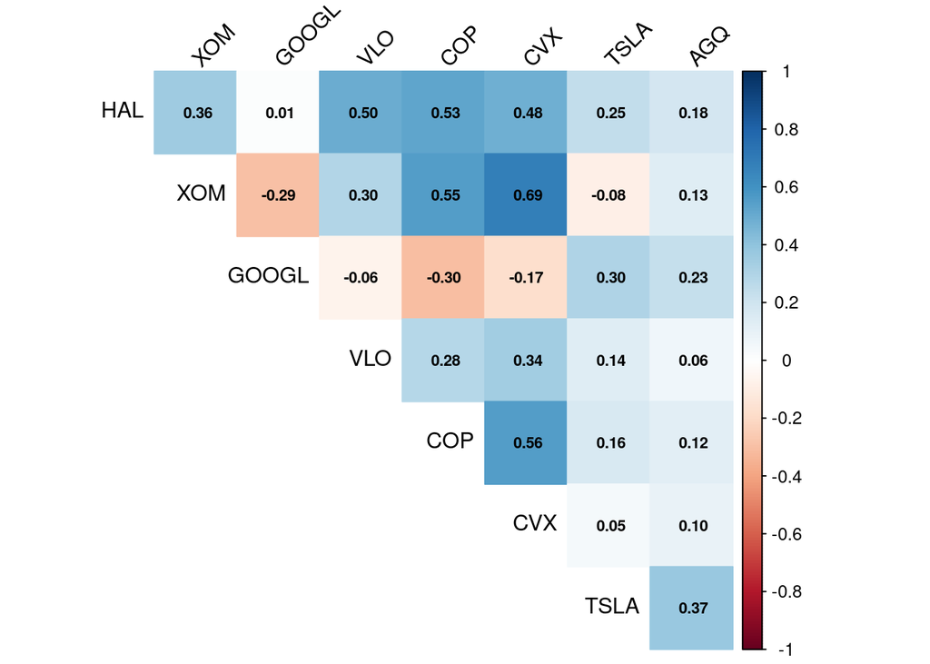

```r
# Visualización tipo heatmap
corrplot(
  cor_matrix,
  method = "color",
  type = "upper",
  tl.col = "black",
  tl.srt = 45,
  addCoef.col = "black",
  number.cex = 0.7,
  diag = FALSE
)
```

```r
#==========================
# MATRIZ DE CORRELACIÓN segundo set de acciones
#==========================

library(corrplot)

# Eliminar timestamp para la prueba de correlación
returns_mat <- modelo2_data %>%
  select(-timestamp)

# Correlación de Pearson
cor_matrix <- cor(returns_mat, use = "complete.obs", method = "pearson")

# Mostrar matriz numérica
round(cor_matrix, 3)
```

```
##         HAL    XOM  GOOGL    VLO    COP    CVX   TSLA   AGQ
## HAL   1.000  0.356  0.012  0.497  0.525  0.480  0.248 0.183
## XOM   0.356  1.000 -0.294  0.295  0.552  0.690 -0.081 0.132
## GOOGL 0.012 -0.294  1.000 -0.063 -0.302 -0.175  0.303 0.232
## VLO   0.497  0.295 -0.063  1.000  0.282  0.343  0.136 0.061
## COP   0.525  0.552 -0.302  0.282  1.000  0.560  0.164 0.123
## CVX   0.480  0.690 -0.175  0.343  0.560  1.000  0.048 0.100
## TSLA  0.248 -0.081  0.303  0.136  0.164  0.048  1.000 0.372
## AGQ   0.183  0.132  0.232  0.061  0.123  0.100  0.372 1.000
```

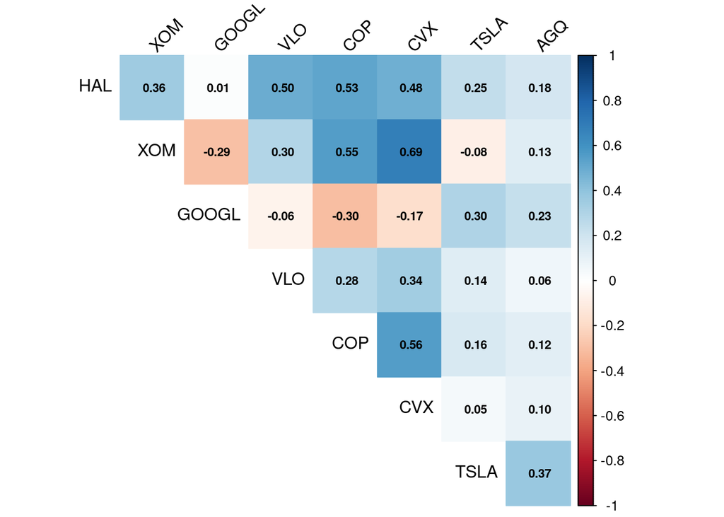

```r
# Visualización tipo heatmap
corrplot(
  cor_matrix,
  method = "color",
  type = "upper",
  tl.col = "black",
  tl.srt = 45,
  addCoef.col = "black",
  number.cex = 0.7,
  diag = FALSE
)
```

```r
#=================================
# MATRIZ DE CORRELACIÓN – MODELO 3
#=================================

returns_mat_T <- modelo3_data %>%
  select(-timestamp)

cor_matrix_T <- cor(returns_mat_T, use = "complete.obs", method = "pearson")

round(cor_matrix_T, 3)
```

```
##        GOOGLT MSFTT AAPLT NVDAT METAT AMZNT
## GOOGLT  1.000 0.199 0.071 0.325 0.480 0.398
## MSFTT   0.199 1.000 0.097 0.292 0.115 0.269
## AAPLT   0.071 0.097 1.000 0.084 0.059 0.060
## NVDAT   0.325 0.292 0.084 1.000 0.415 0.282
## METAT   0.480 0.115 0.059 0.415 1.000 0.368
## AMZNT   0.398 0.269 0.060 0.282 0.368 1.000
```

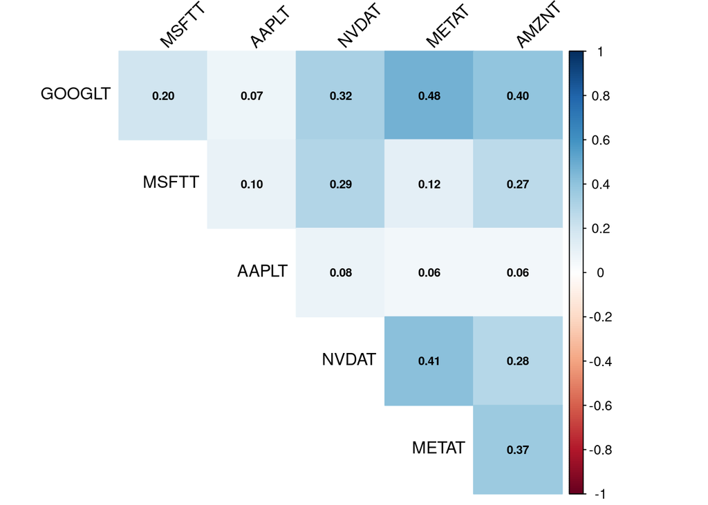

```r
corrplot(
  cor_matrix_T,
  method = "color",
  type = "upper",
  tl.col = "black",
  tl.srt = 45,
  addCoef.col = "black",
  number.cex = 0.7,
  diag = FALSE
)
```

```r
#Ajustar el modelo 1 con HAL como variable dependiente

modelo1 <- lm(
  HAL ~ XOM + GOOGL + VLO + COP + CVX + TSLA + AGQ,
  data = modelo1_data
)

summary(modelo1)
```

```
##
## Call:
## lm(formula = HAL ~ XOM + GOOGL + VLO + COP + CVX + TSLA + AGQ,
##     data = modelo1_data)
##
## Residuals:
##        Min         1Q     Median         3Q        Max
## -0.0158132 -0.0019268 -0.0000764  0.0022519  0.0099087
##
## Coefficients:
##               Estimate Std. Error t value Pr(>|t|)
## (Intercept) -0.0002072  0.0002883  -0.719   0.4734
## XOM         -0.0650947  0.1118152  -0.582   0.5613
## GOOGL        0.1212987  0.0612038   1.982   0.0492 *
## VLO          0.3402437  0.0635238   5.356 2.87e-07 ***
## COP          0.4033476  0.0856607   4.709 5.33e-06 ***
## CVX          0.3594008  0.1425556   2.521   0.0127 *
## TSLA         0.0671649  0.0628860   1.068   0.2871
## AGQ          0.0086205  0.0121226   0.711   0.4780
## ---
## Signif. codes:  0 '***' 0.001 '**' 0.01 '*' 0.05 '.' 0.1 ' ' 1
##
## Residual standard error: 0.003712 on 162 degrees of freedom
##   (167 observations deleted due to missingness)
## Multiple R-squared:  0.4679, Adjusted R-squared:  0.4449
## F-statistic: 20.35 on 7 and 162 DF,  p-value: < 2.2e-16
```

```r
#Ajustar el modelo 2 con XOM como variable dependiente


modelo2 <- lm(
  XOM ~ HAL + GOOGL + VLO + COP + CVX + TSLA + AGQ,
  data = modelo2_data
)

summary(modelo2)
```

```
##
## Call:
## lm(formula = XOM ~ HAL + GOOGL + VLO + COP + CVX + TSLA + AGQ,
##     data = modelo2_data)
##
## Residuals:
##        Min         1Q     Median         3Q        Max
## -0.0083391 -0.0013154 -0.0000759  0.0015280  0.0090407
##
## Coefficients:
##               Estimate Std. Error t value Pr(>|t|)
## (Intercept)  4.529e-05  2.026e-04   0.224  0.82343
## HAL         -3.207e-02  5.509e-02  -0.582  0.56127
## GOOGL       -7.755e-02  4.305e-02  -1.801  0.07350 .
## VLO          6.019e-02  4.814e-02   1.250  0.21304
## COP          2.014e-01  6.213e-02   3.242  0.00144 **
## CVX          6.906e-01  8.638e-02   7.994 2.32e-13 ***
## TSLA        -1.179e-01  4.332e-02  -2.721  0.00722 **
## AGQ          2.047e-02  8.369e-03   2.446  0.01553 *
## ---
## Signif. codes:  0 '***' 0.001 '**' 0.01 '*' 0.05 '.' 0.1 ' ' 1
##
## Residual standard error: 0.002605 on 162 degrees of freedom
##   (167 observations deleted due to missingness)
## Multiple R-squared:  0.5641, Adjusted R-squared:  0.5453
## F-statistic: 29.95 on 7 and 162 DF,  p-value: < 2.2e-16
```

```r
#Ajustar el modelo 3 con GOOGL como variable dependiente


modelo3 <- lm(
  GOOGLT ~ MSFTT + AAPLT + NVDAT + METAT + AMZNT ,
  data = modelo3_data
)

summary(modelo3)
```

```
##
## Call:
## lm(formula = GOOGLT ~ MSFTT + AAPLT + NVDAT + METAT + AMZNT,
##     data = modelo3_data)
##
## Residuals:
##       Min        1Q    Median        3Q       Max
## -0.034379 -0.001210 -0.000012  0.001126  0.034143
##
## Coefficients:
##               Estimate Std. Error t value Pr(>|t|)
## (Intercept) -1.308e-05  1.553e-04  -0.084   0.9329
## MSFTT        6.537e-02  3.414e-02   1.915   0.0560 .
## AAPLT        3.125e-02  4.721e-02   0.662   0.5082
## NVDAT        9.701e-02  3.954e-02   2.454   0.0144 *
## METAT        3.302e-01  3.667e-02   9.003  < 2e-16 ***
## AMZNT        1.894e-01  3.186e-02   5.946 4.62e-09 ***
## ---
## Signif. codes:  0 '***' 0.001 '**' 0.01 '*' 0.05 '.' 0.1 ' ' 1
##
## Residual standard error: 0.003855 on 614 degrees of freedom
##   (1 observation deleted due to missingness)
## Multiple R-squared:  0.3027, Adjusted R-squared:  0.297
## F-statistic:  53.3 on 5 and 614 DF,  p-value: < 2.2e-16
```

```r
#Pruebas de diagnóstico
#MODELO 1
vif(modelo1)  #Detecta multicolinealidad entre las variables independientes.
```

```
##      XOM    GOOGL      VLO      COP      CVX     TSLA      AGQ
## 2.289418 1.349988 1.172582 1.804921 2.174643 1.386754 1.250573
```

```r
bptest(modelo1) #Evalúa si hay heterocedasticidad, es decir, si la varianza de los errores no es constante.
```

```
##
##  studentized Breusch-Pagan test
##
## data:  modelo1
## BP = 32.751, df = 7, p-value = 2.946e-05
```

```r
bgtest(modelo1, order = 1 ) #Este test evalúa autocorrelación en los residuos, es decir, si el error de hoy está relacionado con el de ayer.
```

```
##
##  Breusch-Godfrey test for serial correlation of order up to 1
##
## data:  modelo1
## LM test = 1.733, df = 1, p-value = 0.188
```

```r
#Pruebas de diagnóstico
#MODELO 2
vif(modelo2)  #Detecta multicolinealidad entre las variables independientes.
```

```
##      HAL    GOOGL      VLO      COP      CVX     TSLA      AGQ
## 1.875311 1.355566 1.367045 1.926952 1.620630 1.335482 1.209805
```

```r
bptest(modelo2) #Evalúa si hay heterocedasticidad, es decir, si la varianza de los errores no es constante.
```

```
##
##  studentized Breusch-Pagan test
##
## data:  modelo2
## BP = 6.5672, df = 7, p-value = 0.4753
```

```r
bgtest(modelo2, order = 1 ) #Este test evalúa autocorrelación en los residuos, es decir, si el error de hoy está relacionado con el de ayer.
```

```
##
##  Breusch-Godfrey test for serial correlation of order up to 1
##
## data:  modelo2
## LM test = 1.889, df = 1, p-value = 0.1693
```

```r
#Pruebas de diagnóstico
#MODELO 3
vif(modelo3)
```

```
##    MSFTT    AAPLT    NVDAT    METAT    AMZNT
## 1.151644 1.013911 1.315802 1.323735 1.241749
```

```r
bptest(modelo3)
```

```
##
##  studentized Breusch-Pagan test
##
## data:  modelo3
## BP = 9.5067, df = 5, p-value = 0.09048
```

```r
bgtest(modelo3, order = 1)
```

```
##
##  Breusch-Godfrey test for serial correlation of order up to 1
##
## data:  modelo3
## LM test = 30.353, df = 1, p-value = 3.602e-08
```

### Interpretación del Modelo 1

#### Matriz de correlación

El análisis de correlación muestra que **HAL** presenta una correlación moderada con **COP (0.53)**, **VLO (0.50)** y **CVX (0.48)**. Estas relaciones son positivas, sectoriales y de magnitud intermedia.

Esto implica que los regresores contienen información relevante para explicar los rendimientos de HAL, aunque no capturan completamente toda su dinámica intradía.

#### Diagnósticos econométricos

- **Multicolinealidad:** VIF entre 1.17 y 2.29 → **No se detecta multicolinealidad**.
- **Heterocedasticidad:** Prueba de Breusch‑Pagan (p = 2.94e‑05) → **Existe heterocedasticidad**.
- **Autocorrelación:** Prueba de Breusch‑Godfrey (p = 0.188) → **No hay autocorrelación**.

#### Explicación de la heterocedasticidad en HAL

HAL es una empresa de **servicios petroleros**, por lo que no es ni productora directa ni refinadora de crudo. En este modelo, los rendimientos logarítmicos de HAL se explican en función de siete activos: XOM, GOOGL, VLO, COP, CVX, TSLA y AGQ.

Debido a su modelo de negocio, **HAL es especialmente sensible a shocks sectoriales** como:

- Anuncios de inversión y gasto de capital (CAPEX)
- Cambios en las expectativas futuras del precio del petróleo
- Noticias macroeconómicas
- Incrementos en la volatilidad del mercado energético

En contraste, empresas como **COP, CVX, VLO y XOM** tienden a moverse de forma más directa con el precio spot del petróleo y presentan flujos intradía relativamente más estables.

Como resultado, en periodos de baja volatilidad la correlación sectorial explica adecuadamente los movimientos de HAL. Sin embargo, en episodios de alta volatilidad, HAL exhibe movimientos más amplificados que los previstos por los regresores, generando errores de distinta magnitud.

**Este patrón da lugar a la presencia de heterocedasticidad en el modelo.**

#### Bondad de ajuste

- **R²:** 0.4679
- **R² ajustado:** 0.4449

El modelo explica aproximadamente **44%** de la variación de los rendimientos intradía de HAL, lo cual es razonable para datos de alta frecuencia (30 minutos).

El estadístico F (20.35) con p‑valor menor a 2.2e‑16 indica que el modelo es **globalmente significativo**.

En conjunto, los resultados confirman que HAL presenta una fuerte dependencia del sector energético, especialmente de COP, CVX y VLO. El modelo captura adecuadamente esta relación en el corto plazo, aunque la presencia de heterocedasticidad refleja la naturaleza volátil y amplificada de los rendimientos de HAL.

### Interpretación del Modelo 2

#### Matriz de correlación

La matriz de correlación muestra que **XOM** presenta relaciones positivas y económicamente relevantes con otras empresas del sector energético, en particular con **CVX (0.69)** y **COP (0.55)**. Estas correlaciones reflejan una alta exposición común al mercado petrolero y a factores macroeconómicos compartidos.

En contraste, XOM presenta correlaciones bajas o negativas con activos tecnológicos como **GOOGL (-0.29)** y **TSLA (-0.08)**, lo que evidencia diferencias estructurales entre sectores.

#### Diagnósticos econométricos

- **Multicolinealidad:** VIF entre 1.20 y 1.93 → **No se detecta multicolinealidad**.
- **Heterocedasticidad:** Prueba de Breusch‑Pagan (p = 0.4753) → **No hay heterocedasticidad**.
- **Autocorrelación:** Prueba de Breusch‑Godfrey (p = 0.169) → **No hay autocorrelación**.

#### Explicación de la estabilidad del modelo

En este modelo, los rendimientos logarítmicos de **XOM** se explican a partir de siete activos: HAL, GOOGL, VLO, COP, CVX, TSLA y AGQ. A diferencia de HAL, XOM es una empresa **petrolera integrada**, con actividades diversificadas que abarcan exploración, producción, refinación y comercialización.

Esta estructura integrada permite que los movimientos de XOM sean más proporcionales y homogéneos ante cambios en el entorno económico y energético. Como resultado, las relaciones sectoriales capturadas por la matriz de correlación explican de forma consistente su dinámica intradía.

En consecuencia, la varianza de los errores del modelo se mantiene relativamente constante a lo largo del tiempo, lo que explica la ausencia de heterocedasticidad detectada en las pruebas de diagnóstico.

#### Bondad de ajuste

En conjunto, el Modelo 2 presenta un comportamiento estadístico más estable que el Modelo 1, ya que cumple con los supuestos clásicos del método de Mínimos Cuadrados Ordinarios. Los resultados confirman que XOM se mueve principalmente en función de otras empresas del sector energético, especialmente CVX y COP, lo que es consistente con su carácter de empresa petrolera integrada.

### Interpretación del Modelo 3

#### Matriz de correlación

La matriz de correlación de los rendimientos intradía muestra que **GOOGL** presenta relaciones positivas y económicamente relevantes con otras empresas del sector tecnológico, en particular con **META (0.48)**, **AMZN (0.40)** y **NVDA (0.32)**. Estas correlaciones reflejan una exposición común a factores tecnológicos como publicidad digital, computación en la nube y desarrollo de inteligencia artificial.

En contraste, la correlación con **MSFT (0.20)** y **AAPL (0.07)** es menor, lo que evidencia diferencias en los modelos de negocio y en la dinámica intradía de estas empresas.

#### Diagnósticos econométricos

- **Multicolinealidad:** Los factores de inflación de la varianza (VIF) se mantienen cercanos a 1, lo que indica **ausencia de multicolinealidad** entre las variables explicativas.
- **Heterocedasticidad:** La prueba de Breusch‑Pagan no rechaza la hipótesis nula de homocedasticidad al 5% (p = 0.09), aunque se observa evidencia marginal al 10%, lo que sugiere una varianza de errores relativamente estable.
- **Autocorrelación:** La prueba de Breusch‑Godfrey detecta autocorrelación de primer orden en los residuos, lo cual es consistente con la presencia de dinámica intradía y efectos de persistencia de corto plazo en los rendimientos del sector tecnológico.

#### Explicación económica del modelo

En este modelo, los rendimientos logarítmicos de **GOOGL** se explican en función de cinco empresas tecnológicas líderes: MSFT, AAPL, NVDA, META y AMZN, las cuales representan distintos subsectores dentro del ecosistema tecnológico.

Los resultados muestran que **META** y **AMZN** son los principales determinantes del comportamiento intradía de GOOGL, lo cual es consistente con su exposición común a la publicidad digital, plataformas tecnológicas y servicios en la nube. Asimismo, **NVDA** presenta un efecto positivo y significativo, reflejando el impacto de la infraestructura de inteligencia artificial sobre el sector.

Por el contrario, **AAPL** no resulta estadísticamente significativa, lo que sugiere que su dinámica intradía responde a factores propios del hardware y del consumo, distintos a los principales motores que explican los movimientos de GOOGL.

#### Bondad de ajuste

- **R²:** 0.3027
- **R² ajustado:** 0.297

El modelo explica aproximadamente **30%** de la variación de los rendimientos intradía de GOOGL, lo cual es adecuado considerando la alta frecuencia de los datos (30 minutos) y la heterogeneidad del sector tecnológico.

El estadístico F (53.3) con un p‑valor menor a 2.2e‑16 indica que el modelo es **globalmente significativo**.

En conjunto, el Modelo 3 presenta una buena capacidad explicativa y una estructura estadística coherente con la naturaleza del sector tecnológico. A diferencia del sector energético, donde existe un factor dominante común, la dinámica tecnológica es más heterogénea y presenta persistencia temporal, lo que explica la presencia de autocorrelación sin comprometer la validez del modelo.

Con base en los diagnósticos obtenidos, se sugieren algunos ajustes sencillos para mejorar la interpretación de los modelos. En el **Modelo 1**, donde se detecta heterocedasticidad, una opción práctica es utilizar **errores estándar robustos**, los cuales permiten mantener los mismos coeficientes estimados pero corrigen la inferencia estadística ante cambios en la varianza de los errores. Esto es especialmente útil en datos intradía, donde la volatilidad no suele ser constante. En el caso del **Modelo 3**, la presencia de autocorrelación indica que los rendimientos de GOOGL muestran cierta persistencia en el corto plazo. Para atender este comportamiento, se podría incorporar información del periodo anterior o emplear errores estándar ajustados a autocorrelación, lo que permitiría capturar mejor la dinámica temporal sin modificar la interpretación económica del modelo.